# Risk Prediction - Porto Seguro's Safe Driver

#### Challenge link: https://www.kaggle.com/c/porto-seguro-safe-driver-prediction

#### Data description:

In this competition, you will predict the probability that an auto insurance policy holder files a claim.

In the train and test data, features that belong to similar groupings are tagged as such in the feature names (e.g., ind, reg, car, calc). In addition, feature names include the postfix bin to indicate binary features and cat to indicate categorical features. Features without these designations are either continuous or ordinal. Values of -1 indicate that the feature was missing from the observation. The target columns signifies whether or not a claim was filed for that policy holder.

#### File description:

train.csv contains the training data, where each row corresponds to a policy holder, and the target columns signifies that a claim was filed.

test.csv contains the test data.

sample_submission.csv is submission file showing the correct format.

### Scoring Metric

Submissions are evaluated using the Normalized Gini Coefficient.

During scoring, observations are sorted from the largest to the smallest predictions. Predictions are only used for ordering observations; therefore, the relative magnitude of the predictions are not used during scoring. The scoring algorithm then compares the cumulative proportion of positive class observations to a theoretical uniform proportion.

The Gini Coefficient ranges from approximately 0 for random guessing, to approximately 0.5 for a perfect score. The theoretical maximum for the discrete calculation is (1 - frac_pos) / 2.

Gini = 2*AUC-1

#### Submission file

For each id in the test set, you must predict a probability of an insurance claim in the target column. The file should contain a header and have the following format:

id,target 0,0.1 1,0.9 2,1.0 etc.

# Starting

Let's start importing some libraries that will be useful in the first part

```python
# Importing libraries
import pandas as pd
import numpy as np
from time import time
from sklearn.tree import DecisionTreeClassifier
from sklearn.ensemble import RandomForestClassifier
from sklearn.naive_bayes import GaussianNB
from sklearn.neighbors import KNeighborsClassifier
from xgboost import XGBClassifier
from sklearn.model_selection import train_test_split
from sklearn.model_selection import StratifiedKFold
from sklearn.model_selection import cross_val_score
from sklearn.linear_model import LinearRegression
from sklearn.linear_model import LogisticRegression
from sklearn.preprocessing import StandardScaler
from xgboost import XGBClassifier
from sklearn.preprocessing import LabelEncoder
from sklearn.grid_search import GridSearchCV
```

```python
import seaborn as sns
import matplotlib.pyplot as plt
import missingno as msno
```

```python
from IPython.display import set_matplotlib_formats
set_matplotlib_formats('pdf', 'png')
pd.options.display.float_format = '{:.2f}'.format

%matplotlib inline
%config IPCompleter.greedy=True
```

### Loading the data

Let's set the path variable as the path to the data

```python
# Giving the path for the data
path = '../data/'
```

Loading the train data and showing the first 5 rows

```python
# Loading the train data
train = pd.read_csv(path+'train.csv', na_values = -1)

# Show the first 5 rows
train.head()
```

|  | id | target | ps_ind_01 | ps_ind_02_cat | ps_ind_03 | ps_ind_04_cat | ps_ind_05_cat | ps_ind_06_bin | ps_ind_07_bin | ps_ind_08_bin | ... | ps_calc_11 | ps_calc_12 | ps_calc_13 | ps_calc_14 | ps_calc_15_bin | ps_calc_16_bin | ps_calc_17_bin | ps_calc_18_bin | ps_calc_19_bin | ps_calc_20_bin |
| --- | --- | --- | --- | --- | --- | --- | --- | --- | --- | --- | --- | --- | --- | --- | --- | --- | --- | --- | --- | --- | --- |
| 0 | 7 | 0 | 2 | 2.00 | 5 | 1.00 | 0.00 | 0 | 1 | 0 | ... | 9 | 1 | 5 | 8 | 0 | 1 | 1 | 0 | 0 | 1 |
| 1 | 9 | 0 | 1 | 1.00 | 7 | 0.00 | 0.00 | 0 | 0 | 1 | ... | 3 | 1 | 1 | 9 | 0 | 1 | 1 | 0 | 1 | 0 |
| 2 | 13 | 0 | 5 | 4.00 | 9 | 1.00 | 0.00 | 0 | 0 | 1 | ... | 4 | 2 | 7 | 7 | 0 | 1 | 1 | 0 | 1 | 0 |
| 3 | 16 | 0 | 0 | 1.00 | 2 | 0.00 | 0.00 | 1 | 0 | 0 | ... | 2 | 2 | 4 | 9 | 0 | 0 | 0 | 0 | 0 | 0 |
| 4 | 17 | 0 | 0 | 2.00 | 0 | 1.00 | 0.00 | 1 | 0 | 0 | ... | 3 | 1 | 1 | 3 | 0 | 0 | 0 | 1 | 1 | 0 |

5 rows × 59 columns

```python
# Train data shape
print ('Train data shape:')
train.shape
```

```
Train data shape:
```

```
(595212, 59)
```

Loading the test data and showing the first 5 rows

```python
# load the test data
test = pd.read_csv(path+'test.csv', na_values = -1)

# Show the first 5 rows
test.head()
```

|  | id | ps_ind_01 | ps_ind_02_cat | ps_ind_03 | ps_ind_04_cat | ps_ind_05_cat | ps_ind_06_bin | ps_ind_07_bin | ps_ind_08_bin | ps_ind_09_bin | ... | ps_calc_11 | ps_calc_12 | ps_calc_13 | ps_calc_14 | ps_calc_15_bin | ps_calc_16_bin | ps_calc_17_bin | ps_calc_18_bin | ps_calc_19_bin | ps_calc_20_bin |
| --- | --- | --- | --- | --- | --- | --- | --- | --- | --- | --- | --- | --- | --- | --- | --- | --- | --- | --- | --- | --- | --- |
| 0 | 0 | 0 | 1.00 | 8 | 1.00 | 0.00 | 0 | 1 | 0 | 0 | ... | 1 | 1 | 1 | 12 | 0 | 1 | 1 | 0 | 0 | 1 |
| 1 | 1 | 4 | 2.00 | 5 | 1.00 | 0.00 | 0 | 0 | 0 | 1 | ... | 2 | 0 | 3 | 10 | 0 | 0 | 1 | 1 | 0 | 1 |
| 2 | 2 | 5 | 1.00 | 3 | 0.00 | 0.00 | 0 | 0 | 0 | 1 | ... | 4 | 0 | 2 | 4 | 0 | 0 | 0 | 0 | 0 | 0 |
| 3 | 3 | 0 | 1.00 | 6 | 0.00 | 0.00 | 1 | 0 | 0 | 0 | ... | 5 | 1 | 0 | 5 | 1 | 0 | 1 | 0 | 0 | 0 |
| 4 | 4 | 5 | 1.00 | 7 | 0.00 | 0.00 | 0 | 0 | 0 | 1 | ... | 4 | 0 | 0 | 4 | 0 | 1 | 1 | 0 | 0 | 1 |

5 rows × 58 columns

```python
# Test data shape
print ('Test data shape:')
test.shape
```

```
Test data shape:
```

```
(892816, 58)
```

# Understanding the data

The feture 'target' is our target.

The feature 'id' is the identification of the row.

#### Origin of the feature

Features with 'ind' in the name are features that are related with the client.

Features with 'car' in the name are features that are related with the car.

Features with 'reg' in the name are features that are related with the region.

Features with 'calc' in the name are features that are calculated.

#### Type of the feature

Features with 'cat' in the name are categorical features.

Features with 'bin' in the name are binary features.

Others features can be ordinal or interval

```python
# Creating a function to map the features
def dataMap(data, op=True):

    d_map = []

    for col in data.columns:
        # Defining the feature role
        if (col == 'target'):
            role = 'target'
        elif (col == 'id'):
            role = 'id'
        else:
            role = 'input'

        # Defining the origin
        if ('ind' in col):
            feature_origin = 'client'
        elif ('reg' in col):
            feature_origin = 'region'
        elif ('car' in col):
            feature_origin = 'car'
        elif ('calc'in col):
            feature_origin = 'calculated'
        else:
            feature_origin = 'other'

        # Defining the feature type
        if (('cat' in col) or (col == 'id')):
            feature_type = 'nominal'
        elif (('bin' in col) or (col == 'target')):
            feature_type = 'binary'
        else:
            if (data[col].dtype == np.float64):
                feature_type = 'interval'
            else:
                feature_type = 'ordinal'

        # Defining the data type
        data_type = data[col].dtype

        # Defining the missing data
        NaNs = int(data[col].isnull().sum())
        if(NaNs > 0):
            feature_na = True
            feature_na_q = NaNs
            feature_na_percent = (NaNs/595212)*100
        else:
            feature_na = False
            feature_na_q = 0
            feature_na_percent = 0

        # Create a dict with the information
        c_dict = {'FeatureName': col, 'Origin': feature_origin, 'Role': role, 'FeatureType': feature_type,
                  'DataType': data_type, 'NaN': feature_na, 'NaNs': feature_na_q, 'NaN%': feature_na_percent}

        d_map.append(c_dict)


    data_map = pd.DataFrame(d_map, columns=['FeatureName', 'Origin', 'Role', 'FeatureType', 'DataType', 'NaN', 'NaNs', 'NaN%'])

    if(op==1):
        data_map.set_index('FeatureName', inplace=True)

    return data_map
```

### Maping the data

```python
data_map = dataMap(train)
data_map
```

| FeatureName | Origin | Role | FeatureType | DataType | NaN | NaNs | NaN% |
| --- | --- | --- | --- | --- | --- | --- | --- |
| id | other | id | nominal | int64 | False | 0 | 0.00 |
| target | other | target | binary | int64 | False | 0 | 0.00 |
| ps_ind_01 | client | input | ordinal | int64 | False | 0 | 0.00 |
| ps_ind_02_cat | client | input | nominal | float64 | True | 216 | 0.04 |
| ps_ind_03 | client | input | ordinal | int64 | False | 0 | 0.00 |
| ps_ind_04_cat | client | input | nominal | float64 | True | 83 | 0.01 |
| ps_ind_05_cat | client | input | nominal | float64 | True | 5809 | 0.98 |
| ps_ind_06_bin | client | input | binary | int64 | False | 0 | 0.00 |
| ps_ind_07_bin | client | input | binary | int64 | False | 0 | 0.00 |
| ps_ind_08_bin | client | input | binary | int64 | False | 0 | 0.00 |
| ps_ind_09_bin | client | input | binary | int64 | False | 0 | 0.00 |
| ps_ind_10_bin | client | input | binary | int64 | False | 0 | 0.00 |
| ps_ind_11_bin | client | input | binary | int64 | False | 0 | 0.00 |
| ps_ind_12_bin | client | input | binary | int64 | False | 0 | 0.00 |
| ps_ind_13_bin | client | input | binary | int64 | False | 0 | 0.00 |
| ps_ind_14 | client | input | ordinal | int64 | False | 0 | 0.00 |
| ps_ind_15 | client | input | ordinal | int64 | False | 0 | 0.00 |
| ps_ind_16_bin | client | input | binary | int64 | False | 0 | 0.00 |
| ps_ind_17_bin | client | input | binary | int64 | False | 0 | 0.00 |
| ps_ind_18_bin | client | input | binary | int64 | False | 0 | 0.00 |
| ps_reg_01 | region | input | interval | float64 | False | 0 | 0.00 |
| ps_reg_02 | region | input | interval | float64 | False | 0 | 0.00 |
| ps_reg_03 | region | input | interval | float64 | True | 107772 | 18.11 |
| ps_car_01_cat | car | input | nominal | float64 | True | 107 | 0.02 |
| ps_car_02_cat | car | input | nominal | float64 | True | 5 | 0.00 |
| ps_car_03_cat | car | input | nominal | float64 | True | 411231 | 69.09 |
| ps_car_04_cat | car | input | nominal | int64 | False | 0 | 0.00 |
| ps_car_05_cat | car | input | nominal | float64 | True | 266551 | 44.78 |
| ps_car_06_cat | car | input | nominal | int64 | False | 0 | 0.00 |
| ps_car_07_cat | car | input | nominal | float64 | True | 11489 | 1.93 |
| ps_car_08_cat | car | input | nominal | int64 | False | 0 | 0.00 |
| ps_car_09_cat | car | input | nominal | float64 | True | 569 | 0.10 |
| ps_car_10_cat | car | input | nominal | int64 | False | 0 | 0.00 |
| ps_car_11_cat | car | input | nominal | int64 | False | 0 | 0.00 |
| ps_car_11 | car | input | interval | float64 | True | 5 | 0.00 |
| ps_car_12 | car | input | interval | float64 | True | 1 | 0.00 |
| ps_car_13 | car | input | interval | float64 | False | 0 | 0.00 |
| ps_car_14 | car | input | interval | float64 | True | 42620 | 7.16 |
| ps_car_15 | car | input | interval | float64 | False | 0 | 0.00 |
| ps_calc_01 | calculated | input | interval | float64 | False | 0 | 0.00 |
| ps_calc_02 | calculated | input | interval | float64 | False | 0 | 0.00 |
| ps_calc_03 | calculated | input | interval | float64 | False | 0 | 0.00 |
| ps_calc_04 | calculated | input | ordinal | int64 | False | 0 | 0.00 |
| ps_calc_05 | calculated | input | ordinal | int64 | False | 0 | 0.00 |
| ps_calc_06 | calculated | input | ordinal | int64 | False | 0 | 0.00 |
| ps_calc_07 | calculated | input | ordinal | int64 | False | 0 | 0.00 |
| ps_calc_08 | calculated | input | ordinal | int64 | False | 0 | 0.00 |
| ps_calc_09 | calculated | input | ordinal | int64 | False | 0 | 0.00 |
| ps_calc_10 | calculated | input | ordinal | int64 | False | 0 | 0.00 |
| ps_calc_11 | calculated | input | ordinal | int64 | False | 0 | 0.00 |
| ps_calc_12 | calculated | input | ordinal | int64 | False | 0 | 0.00 |
| ps_calc_13 | calculated | input | ordinal | int64 | False | 0 | 0.00 |
| ps_calc_14 | calculated | input | ordinal | int64 | False | 0 | 0.00 |
| ps_calc_15_bin | calculated | input | binary | int64 | False | 0 | 0.00 |
| ps_calc_16_bin | calculated | input | binary | int64 | False | 0 | 0.00 |
| ps_calc_17_bin | calculated | input | binary | int64 | False | 0 | 0.00 |
| ps_calc_18_bin | calculated | input | binary | int64 | False | 0 | 0.00 |
| ps_calc_19_bin | calculated | input | binary | int64 | False | 0 | 0.00 |
| ps_calc_20_bin | calculated | input | binary | int64 | False | 0 | 0.00 |

```python
data_map = data_map.drop(['target', 'id'])
display(data_map)
```

| FeatureName | Origin | Role | FeatureType | DataType | NaN | NaNs | NaN% |
| --- | --- | --- | --- | --- | --- | --- | --- |
| ps_ind_01 | client | input | ordinal | int64 | False | 0 | 0.00 |
| ps_ind_02_cat | client | input | nominal | float64 | True | 216 | 0.04 |
| ps_ind_03 | client | input | ordinal | int64 | False | 0 | 0.00 |
| ps_ind_04_cat | client | input | nominal | float64 | True | 83 | 0.01 |
| ps_ind_05_cat | client | input | nominal | float64 | True | 5809 | 0.98 |
| ps_ind_06_bin | client | input | binary | int64 | False | 0 | 0.00 |
| ps_ind_07_bin | client | input | binary | int64 | False | 0 | 0.00 |
| ps_ind_08_bin | client | input | binary | int64 | False | 0 | 0.00 |
| ps_ind_09_bin | client | input | binary | int64 | False | 0 | 0.00 |
| ps_ind_10_bin | client | input | binary | int64 | False | 0 | 0.00 |
| ps_ind_11_bin | client | input | binary | int64 | False | 0 | 0.00 |
| ps_ind_12_bin | client | input | binary | int64 | False | 0 | 0.00 |
| ps_ind_13_bin | client | input | binary | int64 | False | 0 | 0.00 |
| ps_ind_14 | client | input | ordinal | int64 | False | 0 | 0.00 |
| ps_ind_15 | client | input | ordinal | int64 | False | 0 | 0.00 |
| ps_ind_16_bin | client | input | binary | int64 | False | 0 | 0.00 |
| ps_ind_17_bin | client | input | binary | int64 | False | 0 | 0.00 |
| ps_ind_18_bin | client | input | binary | int64 | False | 0 | 0.00 |
| ps_reg_01 | region | input | interval | float64 | False | 0 | 0.00 |
| ps_reg_02 | region | input | interval | float64 | False | 0 | 0.00 |
| ps_reg_03 | region | input | interval | float64 | True | 107772 | 18.11 |
| ps_car_01_cat | car | input | nominal | float64 | True | 107 | 0.02 |
| ps_car_02_cat | car | input | nominal | float64 | True | 5 | 0.00 |
| ps_car_03_cat | car | input | nominal | float64 | True | 411231 | 69.09 |
| ps_car_04_cat | car | input | nominal | int64 | False | 0 | 0.00 |
| ps_car_05_cat | car | input | nominal | float64 | True | 266551 | 44.78 |
| ps_car_06_cat | car | input | nominal | int64 | False | 0 | 0.00 |
| ps_car_07_cat | car | input | nominal | float64 | True | 11489 | 1.93 |
| ps_car_08_cat | car | input | nominal | int64 | False | 0 | 0.00 |
| ps_car_09_cat | car | input | nominal | float64 | True | 569 | 0.10 |
| ps_car_10_cat | car | input | nominal | int64 | False | 0 | 0.00 |
| ps_car_11_cat | car | input | nominal | int64 | False | 0 | 0.00 |
| ps_car_11 | car | input | interval | float64 | True | 5 | 0.00 |
| ps_car_12 | car | input | interval | float64 | True | 1 | 0.00 |
| ps_car_13 | car | input | interval | float64 | False | 0 | 0.00 |
| ps_car_14 | car | input | interval | float64 | True | 42620 | 7.16 |
| ps_car_15 | car | input | interval | float64 | False | 0 | 0.00 |
| ps_calc_01 | calculated | input | interval | float64 | False | 0 | 0.00 |
| ps_calc_02 | calculated | input | interval | float64 | False | 0 | 0.00 |
| ps_calc_03 | calculated | input | interval | float64 | False | 0 | 0.00 |
| ps_calc_04 | calculated | input | ordinal | int64 | False | 0 | 0.00 |
| ps_calc_05 | calculated | input | ordinal | int64 | False | 0 | 0.00 |
| ps_calc_06 | calculated | input | ordinal | int64 | False | 0 | 0.00 |
| ps_calc_07 | calculated | input | ordinal | int64 | False | 0 | 0.00 |
| ps_calc_08 | calculated | input | ordinal | int64 | False | 0 | 0.00 |
| ps_calc_09 | calculated | input | ordinal | int64 | False | 0 | 0.00 |
| ps_calc_10 | calculated | input | ordinal | int64 | False | 0 | 0.00 |
| ps_calc_11 | calculated | input | ordinal | int64 | False | 0 | 0.00 |
| ps_calc_12 | calculated | input | ordinal | int64 | False | 0 | 0.00 |
| ps_calc_13 | calculated | input | ordinal | int64 | False | 0 | 0.00 |
| ps_calc_14 | calculated | input | ordinal | int64 | False | 0 | 0.00 |
| ps_calc_15_bin | calculated | input | binary | int64 | False | 0 | 0.00 |
| ps_calc_16_bin | calculated | input | binary | int64 | False | 0 | 0.00 |
| ps_calc_17_bin | calculated | input | binary | int64 | False | 0 | 0.00 |
| ps_calc_18_bin | calculated | input | binary | int64 | False | 0 | 0.00 |
| ps_calc_19_bin | calculated | input | binary | int64 | False | 0 | 0.00 |
| ps_calc_20_bin | calculated | input | binary | int64 | False | 0 | 0.00 |

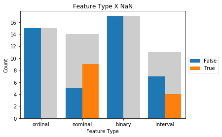

```python
# Graph about the data type
ax = sns.countplot(x="FeatureType", data=data_map, color='#CDCDCD')
ax = sns.countplot(x='FeatureType', hue='NaN', data=data_map, saturation=1)
ax.set_title('Feature Type X NaN')
ax.set_xlabel('Feature Type')
ax.set_ylabel('Count')
ax.legend(bbox_to_anchor=(1, 0.5), loc='center left');
```

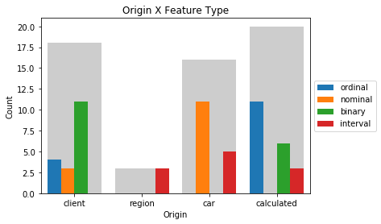

```python
# Graph about the data type
ax = sns.countplot(x="Origin", data=data_map, color='#CDCDCD')
ax = sns.countplot(x='Origin', hue='FeatureType', data=data_map, saturation=1)
ax.set_title('Origin X Feature Type')
ax.set_xlabel('Origin')
ax.set_ylabel('Count')
ax.legend(bbox_to_anchor=(1, 0.5), loc='center left');
```

### Going deep in the NaN

```python
missingValueColumns = train.columns[train.isnull().any()].tolist()
df_null = train[missingValueColumns]
```

```python
missingValueColumns
```

```
['ps_ind_02_cat',
 'ps_ind_04_cat',
 'ps_ind_05_cat',
 'ps_reg_03',
 'ps_car_01_cat',
 'ps_car_02_cat',
 'ps_car_03_cat',
 'ps_car_05_cat',
 'ps_car_07_cat',
 'ps_car_09_cat',
 'ps_car_11',
 'ps_car_12',
 'ps_car_14']
```

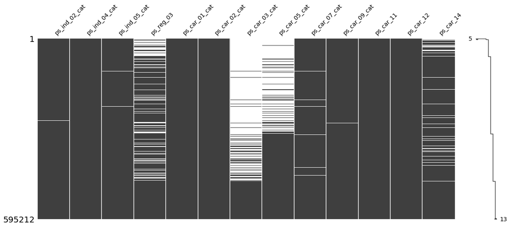

```python
sorted_data = msno.nullity_sort(df_null, sort='ascending')
msno.matrix(sorted_data,figsize=(20,8),fontsize=14)
```

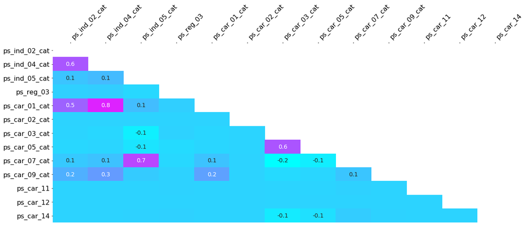

```python
msno.heatmap(df_null,figsize=(20,8),cmap=plt.cm.cool)
```

### Correlation between interval data

```python
cols_interval = data_map[(data_map.FeatureType == 'interval')].index
```

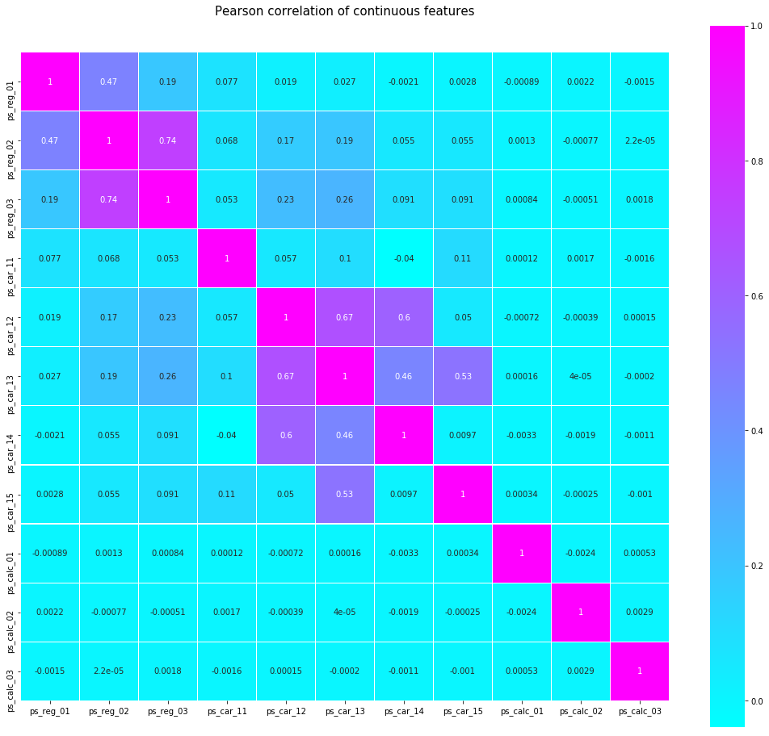

```python
plt.figure(figsize=(18,16))
plt.title('Pearson correlation of continuous features', y=1.05, size=15)
sns.heatmap(train[cols_interval].corr(),linewidths=0.1,vmax=1.0, square=True, cmap=plt.cm.cool, linecolor='white', annot=True)
```

### Feature importance

```python
# Function to get the importance

def featureImportance(data, op=True):

    X = data.drop(['target', 'id'], axis=1)
    y = data['target']

    features = X.columns.values

    clf = RandomForestClassifier(n_estimators=200, max_features=6, min_samples_leaf=10, min_samples_split=70, criterion='gini', max_depth=10, n_jobs=-1)
    X.fillna(-1, inplace=True)
    clf.fit(X,y)

    importance = clf.feature_importances_

    df_imp = pd.DataFrame(data={'Feature': features, 'Importance': importance})

    if op:
        df_imp.set_index('Feature', inplace=True)

    return df_imp
```

```python
df_imp = featureImportance(train)
```

```python
df_imp
```

| Feature | Importance |
| --- | --- |
| ps_ind_01 | 0.02 |
| ps_ind_02_cat | 0.01 |
| ps_ind_03 | 0.04 |
| ps_ind_04_cat | 0.01 |
| ps_ind_05_cat | 0.06 |
| ps_ind_06_bin | 0.02 |
| ps_ind_07_bin | 0.02 |
| ps_ind_08_bin | 0.00 |
| ps_ind_09_bin | 0.00 |
| ps_ind_10_bin | 0.00 |
| ps_ind_11_bin | 0.00 |
| ps_ind_12_bin | 0.00 |
| ps_ind_13_bin | 0.00 |
| ps_ind_14 | 0.00 |
| ps_ind_15 | 0.03 |
| ps_ind_16_bin | 0.01 |
| ps_ind_17_bin | 0.04 |
| ps_ind_18_bin | 0.00 |
| ps_reg_01 | 0.02 |
| ps_reg_02 | 0.04 |
| ps_reg_03 | 0.07 |
| ps_car_01_cat | 0.03 |
| ps_car_02_cat | 0.01 |
| ps_car_03_cat | 0.02 |
| ps_car_04_cat | 0.03 |
| ps_car_05_cat | 0.01 |
| ps_car_06_cat | 0.02 |
| ps_car_07_cat | 0.03 |
| ps_car_08_cat | 0.01 |
| ps_car_09_cat | 0.01 |
| ps_car_10_cat | 0.00 |
| ps_car_11_cat | 0.02 |
| ps_car_11 | 0.01 |
| ps_car_12 | 0.03 |
| ps_car_13 | 0.10 |
| ps_car_14 | 0.04 |
| ps_car_15 | 0.02 |
| ps_calc_01 | 0.01 |
| ps_calc_02 | 0.01 |
| ps_calc_03 | 0.02 |
| ps_calc_04 | 0.01 |
| ps_calc_05 | 0.01 |
| ps_calc_06 | 0.01 |
| ps_calc_07 | 0.01 |
| ps_calc_08 | 0.01 |
| ps_calc_09 | 0.01 |
| ps_calc_10 | 0.02 |
| ps_calc_11 | 0.02 |
| ps_calc_12 | 0.01 |
| ps_calc_13 | 0.01 |
| ps_calc_14 | 0.02 |
| ps_calc_15_bin | 0.00 |
| ps_calc_16_bin | 0.00 |
| ps_calc_17_bin | 0.00 |
| ps_calc_18_bin | 0.00 |
| ps_calc_19_bin | 0.00 |
| ps_calc_20_bin | 0.00 |

```python
new_data_map = data_map.merge(df_imp, left_index=True, right_index=True, how='left')
display(new_data_map.sort_values(['Importance'], ascending=False))
```

| FeatureName | Origin | Role | FeatureType | DataType | NaN | NaNs | NaN% | Importance |
| --- | --- | --- | --- | --- | --- | --- | --- | --- |
| ps_car_13 | car | input | interval | float64 | False | 0 | 0.00 | 0.10 |
| ps_reg_03 | region | input | interval | float64 | True | 107772 | 18.11 | 0.07 |
| ps_ind_05_cat | client | input | nominal | float64 | True | 5809 | 0.98 | 0.06 |
| ps_ind_17_bin | client | input | binary | int64 | False | 0 | 0.00 | 0.04 |
| ps_reg_02 | region | input | interval | float64 | False | 0 | 0.00 | 0.04 |
| ps_ind_03 | client | input | ordinal | int64 | False | 0 | 0.00 | 0.04 |
| ps_car_14 | car | input | interval | float64 | True | 42620 | 7.16 | 0.04 |
| ps_ind_15 | client | input | ordinal | int64 | False | 0 | 0.00 | 0.03 |
| ps_car_07_cat | car | input | nominal | float64 | True | 11489 | 1.93 | 0.03 |
| ps_car_12 | car | input | interval | float64 | True | 1 | 0.00 | 0.03 |
| ps_car_01_cat | car | input | nominal | float64 | True | 107 | 0.02 | 0.03 |
| ps_car_04_cat | car | input | nominal | int64 | False | 0 | 0.00 | 0.03 |
| ps_car_15 | car | input | interval | float64 | False | 0 | 0.00 | 0.02 |
| ps_reg_01 | region | input | interval | float64 | False | 0 | 0.00 | 0.02 |
| ps_calc_14 | calculated | input | ordinal | int64 | False | 0 | 0.00 | 0.02 |
| ps_calc_10 | calculated | input | ordinal | int64 | False | 0 | 0.00 | 0.02 |
| ps_car_11_cat | car | input | nominal | int64 | False | 0 | 0.00 | 0.02 |
| ps_calc_11 | calculated | input | ordinal | int64 | False | 0 | 0.00 | 0.02 |
| ps_ind_01 | client | input | ordinal | int64 | False | 0 | 0.00 | 0.02 |
| ps_ind_07_bin | client | input | binary | int64 | False | 0 | 0.00 | 0.02 |
| ps_car_03_cat | car | input | nominal | float64 | True | 411231 | 69.09 | 0.02 |
| ps_car_06_cat | car | input | nominal | int64 | False | 0 | 0.00 | 0.02 |
| ps_ind_06_bin | client | input | binary | int64 | False | 0 | 0.00 | 0.02 |
| ps_calc_03 | calculated | input | interval | float64 | False | 0 | 0.00 | 0.02 |
| ps_calc_02 | calculated | input | interval | float64 | False | 0 | 0.00 | 0.01 |
| ps_calc_13 | calculated | input | ordinal | int64 | False | 0 | 0.00 | 0.01 |
| ps_ind_16_bin | client | input | binary | int64 | False | 0 | 0.00 | 0.01 |
| ps_calc_01 | calculated | input | interval | float64 | False | 0 | 0.00 | 0.01 |
| ps_calc_07 | calculated | input | ordinal | int64 | False | 0 | 0.00 | 0.01 |
| ps_calc_08 | calculated | input | ordinal | int64 | False | 0 | 0.00 | 0.01 |
| ps_ind_04_cat | client | input | nominal | float64 | True | 83 | 0.01 | 0.01 |
| ps_calc_06 | calculated | input | ordinal | int64 | False | 0 | 0.00 | 0.01 |
| ps_ind_02_cat | client | input | nominal | float64 | True | 216 | 0.04 | 0.01 |
| ps_calc_05 | calculated | input | ordinal | int64 | False | 0 | 0.00 | 0.01 |
| ps_car_02_cat | car | input | nominal | float64 | True | 5 | 0.00 | 0.01 |
| ps_calc_09 | calculated | input | ordinal | int64 | False | 0 | 0.00 | 0.01 |
| ps_car_09_cat | car | input | nominal | float64 | True | 569 | 0.10 | 0.01 |
| ps_calc_04 | calculated | input | ordinal | int64 | False | 0 | 0.00 | 0.01 |
| ps_calc_12 | calculated | input | ordinal | int64 | False | 0 | 0.00 | 0.01 |
| ps_car_05_cat | car | input | nominal | float64 | True | 266551 | 44.78 | 0.01 |
| ps_car_11 | car | input | interval | float64 | True | 5 | 0.00 | 0.01 |
| ps_car_08_cat | car | input | nominal | int64 | False | 0 | 0.00 | 0.01 |
| ps_ind_08_bin | client | input | binary | int64 | False | 0 | 0.00 | 0.00 |
| ps_ind_09_bin | client | input | binary | int64 | False | 0 | 0.00 | 0.00 |
| ps_ind_18_bin | client | input | binary | int64 | False | 0 | 0.00 | 0.00 |
| ps_calc_17_bin | calculated | input | binary | int64 | False | 0 | 0.00 | 0.00 |
| ps_calc_19_bin | calculated | input | binary | int64 | False | 0 | 0.00 | 0.00 |
| ps_calc_16_bin | calculated | input | binary | int64 | False | 0 | 0.00 | 0.00 |
| ps_calc_18_bin | calculated | input | binary | int64 | False | 0 | 0.00 | 0.00 |
| ps_calc_15_bin | calculated | input | binary | int64 | False | 0 | 0.00 | 0.00 |
| ps_calc_20_bin | calculated | input | binary | int64 | False | 0 | 0.00 | 0.00 |
| ps_ind_14 | client | input | ordinal | int64 | False | 0 | 0.00 | 0.00 |
| ps_car_10_cat | car | input | nominal | int64 | False | 0 | 0.00 | 0.00 |
| ps_ind_12_bin | client | input | binary | int64 | False | 0 | 0.00 | 0.00 |
| ps_ind_11_bin | client | input | binary | int64 | False | 0 | 0.00 | 0.00 |
| ps_ind_13_bin | client | input | binary | int64 | False | 0 | 0.00 | 0.00 |
| ps_ind_10_bin | client | input | binary | int64 | False | 0 | 0.00 | 0.00 |

# Basic Model

Before use feature engineering I'am going to train and evaluate (with Gini) a model. I'am going to do that because I want to know how will be the score in a model with no feature enginnering, so when I use this tool I will have a idea of the result with no feature enginnering to compare.

Creating the X and y for the basic model and filling the nan with -1.

I will use only Naive Bayes and Decision Tree because they are faster.

#### Function for a Cross Validation

```python
# Defining the function
def crossValidation(data, model):
    # Start to count the time
    start = time()

    # Creating X and y
    X = data.drop(['target', 'id'], axis=1)
    y = data['target']

    X.fillna(-1, inplace=True)

    X_train, X_test, y_train, y_test = train_test_split(X, y, test_size = 0.25, random_state = 0)

    model.fit(X_train, y_train)

    cross_score = cross_val_score(model, X_test, y_test, cv=3, scoring='roc_auc')

    print("Gini Score: %.5f" % ((cross_score.mean()*2)-1))

    # Stop the time count
    end = time()

    # Print the time
    print ("Time: {:.4f} seconds".format(end - start))
```

#### Basic Model with Decision Tree

```python
basicModelDTree = DecisionTreeClassifier(random_state=28)
crossValidation(train, basicModelDTree)
```

```
Gini Score: 0.01405
Time: 22.1035 seconds
```

#### Basic Model with Naive Bayes

```python
basicModelNaiveBayes = GaussianNB()
crossValidation(train, basicModelNaiveBayes)
```

```
Gini Score: 0.22870
Time: 1.6658 seconds
```

# Feature Engineering

## Missing data

##### ps_car_05_cat

will be removed because have 44.78% of missing data and the importance of this feature is only 0.01

##### ps_car_03_cat

will be removed because have 69.09% of missing

##### ps_ind_02_cat

will be removed because have missing data and the importance of this features is only 0.01

```python
toRemove =['ps_car_05_cat', 'ps_car_03_cat', 'ps_ind_02_cat']
train = train.drop(toRemove, axis=1)
test = test.drop(toRemove, axis=1)
```

```python
def predictFeatures(model, data, dataMissing, column, op=False):

    X_train = data.drop(['id', column], axis=1)
    y_pred = data[column]

    if op:
        sc = StandardScaler()
        X_train = sc.fit_transform(X_train)

    model.fit(X_train, y_pred)

    X_pred = dataMissing.drop(['id', column], axis=1)

    if op:
        X_pred = sc.transform(X_pred)

    y_pred = model.predict(X_pred)

    dataMissing[column] = y_pred

    data = data.append(dataMissing)

    return data
```

```python
def missingFeatures(data):

    cols_with_missing_values = data.columns[data.isnull().any()].tolist()
    cols_without_missing_values = data.columns[data.isnull().any()==0].tolist()

    cat_cols_without_missing_values = [c for c in cols_without_missing_values if ('cat' in c) or ('id' in c)]
    bin_cols_without_missing_values = [c for c in cols_without_missing_values if ('bin' in c)]
    other_cols_without_missing_values = [c for c in cols_without_missing_values if ('bin' not in c and 'cat' not in c and 'target' not in c and 'id' not in c)]

    for column in data.columns:

        if column != 'id' and column != 'target':
            if column in cols_with_missing_values:
                print('##################################################################')
                print('Starting treatment of:', column)
                if 'cat' in column:
                    print('Missings:', data[column].isnull().sum())
                    cols = cat_cols_without_missing_values
                    cols.append(column)
                    toTrain = data[cols][(data[column].notnull())]
                    toPredict = data[cols][(data[column].isnull())]
                    newColumn = predictFeatures(LogisticRegression(random_state=0), toTrain, toPredict, column, True)
                    newColumn = newColumn.sort_values(['id'], ascending=True)
                    data[column] = newColumn[column]
                    print ('Finished')
                    print ('Missings: ', data[column].isnull().sum())
                    print ('##################################################################')

                elif 'reg' in column:
                    print('Missings:', data[column].isnull().sum())
                    toTrain = data[['id','ps_reg_02','ps_reg_03']][(data['ps_reg_03'].notnull())]
                    toPredict = data[['id','ps_reg_02','ps_reg_03']][(data['ps_reg_03'].isnull())]
                    newColumn = predictFeatures(LinearRegression(n_jobs=-1), toTrain, toPredict, column, False)
                    newColumn = newColumn.sort_values(['id'], ascending=True)
                    data[column] = newColumn[column]
                    print ('Finished')
                    print ('Missings: ', data[column].isnull().sum())
                    print ('##################################################################')

                elif 'car_12' in column:
                    print('Missings:', data[column].isnull().sum())
                    toTrain = data[['id','ps_car_13','ps_car_12']][(data['ps_car_12'].notnull())]
                    toPredict= data[['id','ps_car_13','ps_car_12']][(data['ps_car_12'].isnull())]
                    newColumn = predictFeatures(LinearRegression(n_jobs=-1), toTrain, toPredict, column, True)
                    newColumn = newColumn.sort_values(['id'], ascending=True)
                    data[column] = newColumn[column]
                    print ('Finished')
                    print ('Missings: ', data[column].isnull().sum())
                    print ('##################################################################')

                else:
                    print('Missings:', data[column].isnull().sum())
                    data[column].fillna(data[column].mean(), inplace=True)
                    print ('Finished')
                    print ('Missings: ', data[column].isnull().sum())
                    print ('##################################################################')

        else:
            continue

    return data
```

```python
train = missingFeatures(train)
test = missingFeatures(test)
```

```
##################################################################
Starting treatment of: ps_ind_04_cat
Missings: 83
Finished
Missings:  0
##################################################################
##################################################################
Starting treatment of: ps_ind_05_cat
Missings: 5809
Finished
Missings:  0
##################################################################
##################################################################
Starting treatment of: ps_reg_03
Missings: 107772
Finished
Missings:  0
##################################################################
##################################################################
Starting treatment of: ps_car_01_cat
Missings: 107
Finished
Missings:  0
##################################################################
##################################################################
Starting treatment of: ps_car_02_cat
Missings: 5
Finished
Missings:  0
##################################################################
##################################################################
Starting treatment of: ps_car_07_cat
Missings: 11489
Finished
Missings:  0
##################################################################
##################################################################
Starting treatment of: ps_car_09_cat
Missings: 569
Finished
```

[output cut: 59 more lines]

```
Finished
Missings:  0
##################################################################
##################################################################
Starting treatment of: ps_car_11
Missings: 1
Finished
Missings:  0
##################################################################
##################################################################
Starting treatment of: ps_car_14
Missings: 63805
Finished
Missings:  0
##################################################################
```

## New Calc

Creating a new feature called new_calc that will be a sum of all the calculated features who are not binaries. And after I will delet the calc features.

```python
features = train.columns.tolist()
features = [c for c in features if 'target' not in c and 'id' not in c]

features_cat = [c for c in features if 'cat' in c]
features_bin = [c for c in features if 'bin' in c]
features_num = [c for c in features if c not in features_bin and c not in features_cat]
features_calc = [c for c in features_num if 'calc' in c]
features_reg = [c for c in features_num if 'reg' in c]
features_car = [c for c in features_num if 'car' in c]

train['new_calc'] = 1
test['new_calc'] = 1
for f in features_calc:
    train['new_calc'] = train['new_calc'] + train[f]
    test['new_calc'] = test['new_calc'] + test[f]

train = train.drop(features_calc, axis=1)
test = test.drop(features_calc, axis=1)
```

## Label Encoder in cat features

Let's use Label Encoder in all cat features

IMPORTANT: I tried to use OneHotEncoder and treat the dammy varibles, but that only took my score dow.

```python
for f in features_cat:
    le = LabelEncoder()
    le.fit(train[f])
    train[f] = le.fit_transform(train[f])
    test[f] = le.fit_transform(test[f])
```

## Evaluating some models

Let's evaluate some models

#### Decision Tree

```python
clf = DecisionTreeClassifier(random_state=28)
crossValidation(train, clf)
```

```
Gini Score: 0.01209
Time: 14.6640 seconds
```

#### Naive Bayes

```python
cols = train.columns.tolist()
features_toScale = [c for c in cols if 'id' not in c and 'target' not in c]
sc = StandardScaler()
train2 = train.copy()
train2[features_toScale] = sc.fit_transform(train2[features_toScale])


clf = GaussianNB()
crossValidation(train2, clf)
```

```
Gini Score: 0.21898
Time: 1.2825 seconds
```

#### Random Forest

```python
clf = RandomForestClassifier(random_state=28, n_jobs=8)
crossValidation(train, clf)
```

```
Gini Score: 0.08044
Time: 5.8731 seconds
```

#### XGBClassifier

```python
clf = XGBClassifier(random_state=28, n_jobs=8)
crossValidation(train, clf)
```

```
Gini Score: 0.25848
Time: 20.3956 seconds
```

#### KNN

```python
clf = KNeighborsClassifier(n_neighbors = 10, n_jobs=8)
crossValidation(train2, clf)
```

```
Gini Score: 0.05001
Time: 1278.4630 seconds
```

## Grid Search

```python
def gridSearchModel(model, parameters, data):
    start = time()

    print('Grid Search starting...')
    X = data.drop(['target', 'id'], axis=1)
    y = data['target']

    X_train, X_test, y_train, y_test = train_test_split(X, y, test_size = 0.25, random_state = 0)
    print('Split done...')

    grid_obj = GridSearchCV(model, parameters, scoring='roc_auc')
    print('grid_obj done...')

    grid_obj = grid_obj.fit(X, y)
    print('grid_obj trained...')

    model = grid_obj.best_estimator_
    print('model done...')

    end = time()

    print('Parameters: ', model.get_params())
    print ("Time: {:.4f} seconds".format(end - start))

    return model
```

## Creating a submission file

```python
def submissionCreate(data, test, model, name):
    # Start to count the time
    start = time()


    # Creating X and y
    X = data.drop(['target', 'id'], axis=1)
    y = data['target']


    print('Train starting...')

    model.fit(X, y)

    id_test = test['id'].values

    test_pred = test.drop(['id'], axis=1)

    submission = pd.DataFrame(columns=['id','target'])
    submission['target'] = model.predict_proba(test_pred)[:,1]
    submission['id'] = id_test
    submission.to_csv(name, index=False)

    # Stop the time count
    end = time()

    # Print the time
    print ("Time: {:.4f} seconds".format(end - start))
```

```python
print('##################################################################')
print('Creating XGB')

params = {}
params['learning_rate'] = [0.01, 0.02]
params['n_estimators'] = [800, 1000]
params['max_depth'] = [4, 6]
params['subsample'] = [0.9]
params['colsample_bytree'] = [0.9]
params['n_jobs'] = [8]
params['random_state'] = [28]

clf = gridSearchModel(XGBClassifier(), params, train)
crossValidation(train, clf)
submissionCreate(train, test, clf, '/output/submission_xgb.csv')
print('##################################################################')
```

```
##################################################################
Creating XGB
Grid Search starting...
Split done...
grid_obj done...
```